# William F. Lamb

William F. Lamb

[Github](https://github.com/lambwf/)

# About me

I am a senior researcher at the Potsdam Institute for Climate Impact Research. My work mainly focuses on emissions trends, climate policy analysis and carbon dioxide removal.

Here you can find links to some of my work, as well as additional figures, data and analysis. All of my analysis and code is open source and can be found on Github.

The national greenhouse gas inventories are messy and this dataset makes them tidy. Figures are available here, as well as links to the data repository.

Tidy GHG Inventories

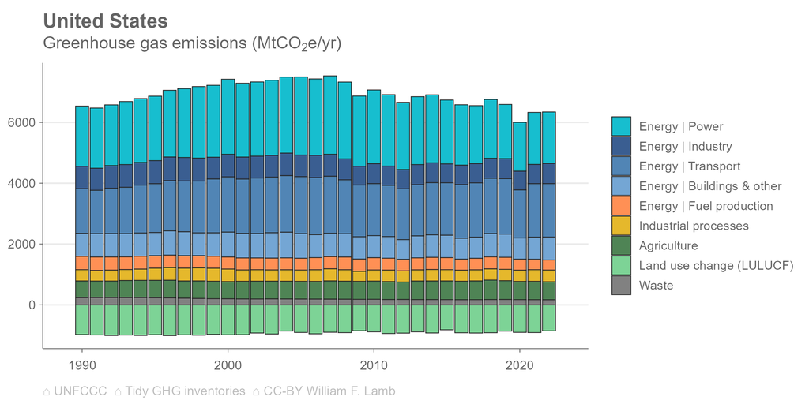

Since 2022 I have co-led the Global Emissions Trends chapter of the UNEP Emissions Gap Report. Here are figures from the 2025 version.

UNEP Emissions Gap Report 2025

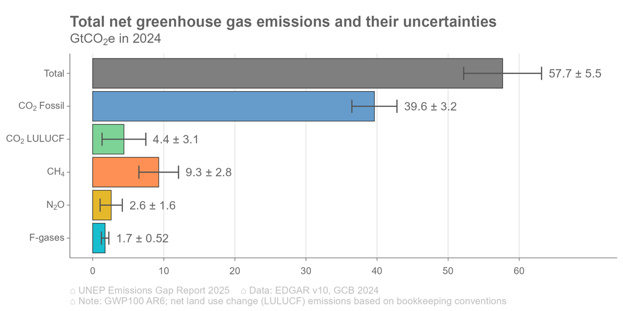

This paper provides updates between IPCC reports of some the most important indicators of global climate change.

Indicators of global climate change 2024

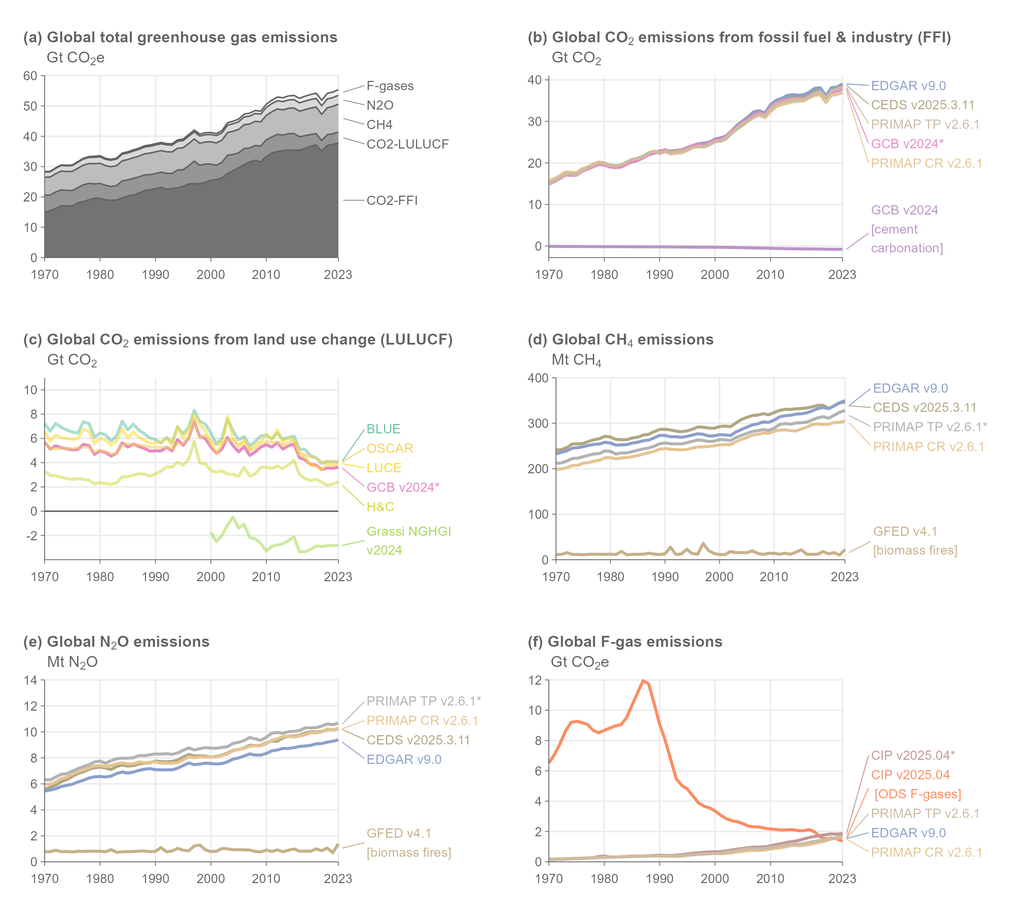

Since 2022 I have co-led the Global Emissions Trends chapter of the UNEP Emissions Gap Report. Here are figures from the 2024 version.

UNEP Emissions Gap Report 2024

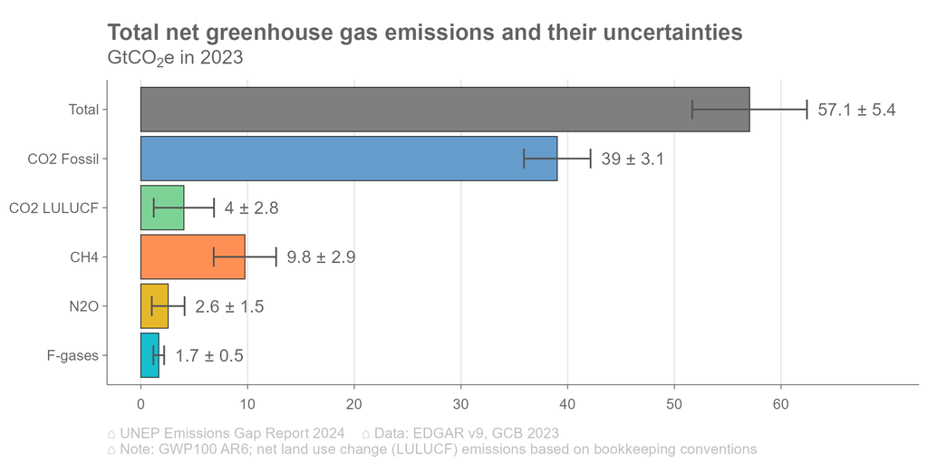

A current list of countries that have peaked in GHG emissions and reduced for more than 10 years.

Countries that have reached peak emissions

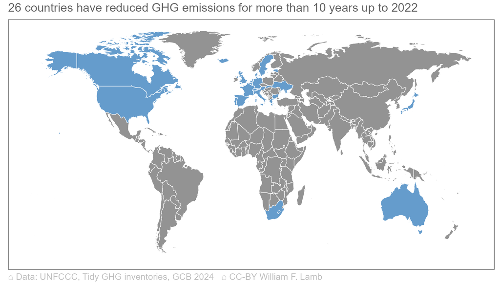

This paper provides updates between IPCC reports of some the most important indicators of global climate change.

Indicators of global climate change 2023

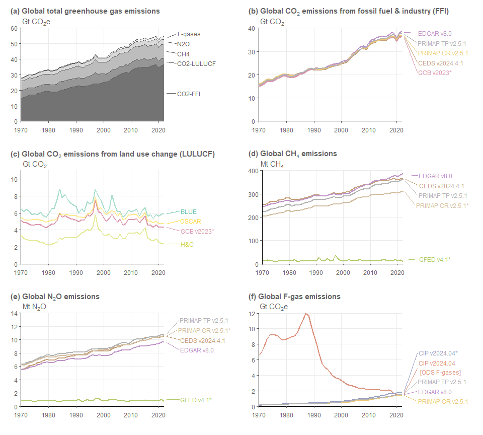

This is a nice scientific report on carbon dioxide removal. We are currently planning a third version for 2026.

The State of Carbon Dioxide Removal

[figure not shown]

When a group of climate mitigation scientists dabbled in discourses and tried to characterise climate denial in the policy realm… Click here for a brief history.

Discourses of climate delay

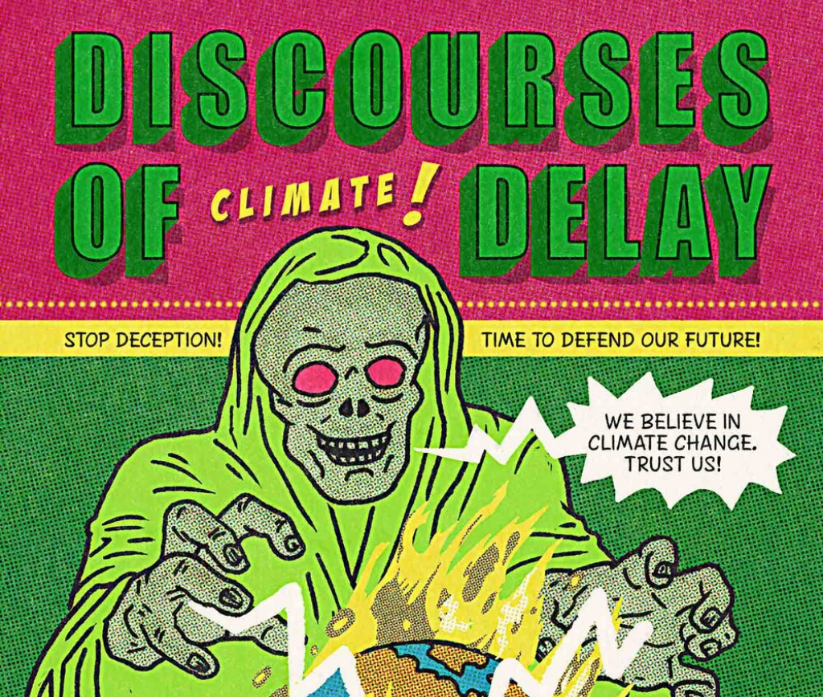

I was a chapter scientist in the last WGIII assessment and ended up producing all kinds of emissions analysis and figures across the report.

IPCC 6th Assessment WGIII Report

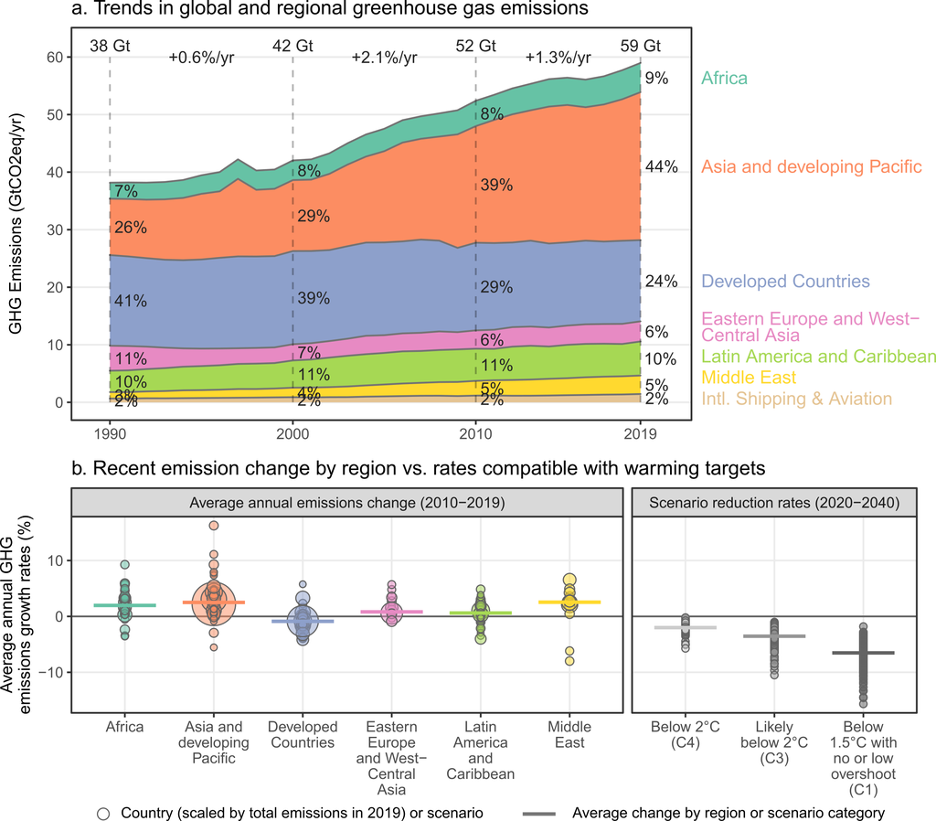

# Selected outreach

**2026**

Interviewed by Süddeutsche Zeitung on Indicators of Global Climate Change (11/06) [[link](https://www.sueddeutsche.de/wissen/klimabericht-temperaturanstieg-co2-emissionen-igcc-li.3495261?reduced=true)]

Interviewed by Tagespiegel on the State of Carbon Dioxide Removal Edition 3 (02/06) [[link](https://background.tagesspiegel.de/energie-und-klima/briefing/nachfrageproblem-behindert-hochlauf-von-cdr)]

Presented at the Launch of the State of Carbon Dioxide Removal Edition 3 (02/06) [[link](https://www.youtube.com/live/pwrjKzXSvfg)]

Quoted in the Guardian on the State of Carbon Dioxide Removal Edition 3 (02/06) [[link](https://www.theguardian.com/environment/2026/jun/02/new-ways-remove-co2-from-atmosphere-carbon-dioxide-removal?CMP=share_btn_url)]

Invited lecture to the Humboldt Climate Fellows on carbon dioxide removal (26/01)

Interviewed by the Guardian on climate policy and decoupling in emissions and GDP (16/01) [[link](https://www.theguardian.com/environment/2026/feb/11/is-romania-blueprint-economic-growth-low-emissions)]

Quoted in Carbon Brief on the impact of the US withdrawl from UNFCCC global emissions reporting (08/01) [[link](https://www.carbonbrief.org/qa-what-trumps-us-exit-from-unfccc-and-ipcc-could-mean-for-climate-action/)]

**2025**

Presented the UNEP Emissions Gap Report at a UNFCCC brown bag lunch (09/12)

Attended the IPCC AR7 first Lead Author Meeting in Paris (01/12) [[link](https://bsky.app/profile/pik-potsdam.bsky.social/post/3m7id4vobzk2j)]

Contributed to a COP30 side-event panel on carbon dioxide removal and the IPCC task force on inventories (14/11)

Interviewed by Bloomberg for an article on China’s NDC and countries that have peaked in emissions (24/09) [link]

Invited presentation and panel discussion at the Tyndall Assembly Conference (09/09)

Nominated as Lead Author of the IPCC 7th Assessment Report (19/08) [[link](https://www.ipcc.ch/2025/08/18/pr-ar7-authors/)]

Invited presentation at the Environmental Defence Fund Science Days (24/06)

Participated in a press conference at the UNFCCC June Climate Meetings in Bonn for the “Indicators of Global Climate Change 2024” publication (19/06) [[link](https://unfccc-events.azureedge.net/SB62_106597/agenda)]

Contributed to an Informal Dialogue at the UNFCCC June Climate Meetings on 1.5C science and narratives (19/06)

Invited expert to the 17th Meeting of the Research Dialogue, UNFCCC June Climate Meetings - though really Pep Canadell did all the work! (17/06) [[link](https://unfccc.int/event/seventeenth-meeting-of-the-research-dialogue-mandated-event)]

Interviewed by Südwestrundfunk and tagesschau.de on the “Indicators of Global Climate Change 2024” publication (17/06) [[link](https://www.tagesschau.de/wissen/klima/bericht-zustand-klima-100.html)]

Interviewed by ARD for a piece on greenhouse gas emissions reporting (16/06)

Participated in a UK Science Media Centre Briefing for the “Indicators of Global Climate Change 2024” publication (12/06)

Interviewed for an article in DeSmog on the topic of Climate Delay (11/06) [[link](https://www.desmog.com/2025/07/30/denial-delay-how-the-far-right-is-orchestrating-climate-backlash-european-parliament/)]

Invited to present Discourses of Climate Delay at a GIZ event on Behavioural Change (27/03)

Invited to present on the IPCC 7th Assessment Report outline by the German-IPCC coordination group (20/03)

Invited as Lead Author of the UNEP Emissions Gap Report 2025 (05/02)

**2024**

Nominated to attend the IPCC Scoping Meeting for the 7th Assessment Report (09/12) [[photo!](https://raw.githubusercontent.com/lambwf/lambwf.github.io/refs/heads/master/plots/ar7-scoping-meeting.jpg)]

Participated in the preparation of evidence submitted by IPCC authors to the International Court of Justice for their case on the “legal obligations of countries in preventing climate change” (26/11) [[link](https://www.icj-cij.org/sites/default/files/case-related/187/187-20241126-pre-01-00-en.pdf)]

Invited to present to the European Commission DG Clima division on the Emissions Gap Report 2024 (07/11)

Invited to present to the US Office of the Special Presidential Envoy for Climate on the Emissions Gap Report 2024 (31/10)

Invited as Lead Author of the UNEP Emissions Gap Report 2024 (08/02)

**2023**

Invited to a roundtable on climate misinformation with the Chief Scientific Advisor to the UK Government (21/06)

Poor records and bad memory before this… :)

# Selected publications

**2026**

Piers M. Forster, Tristram Walsh, Chris Smith, William F. Lamb, Robin Lamboll, et al. (2026). *Indicators of Global Climate Change 2025: annual update of key indicators of the state of the climate system and human influence.* Earth System Science Data, 18(6): 3889–3933. https://doi.org/10.5194/essd-18-3889-2026

Morgan Edwards, Oliver Geden, Matthew J. Gidden, William F. Lamb, Jan C. Minx, et al. (2026). *The State of Carbon Dioxide Removal - 3rd Edition.* https://doi.org/10.17605/OSF.IO/ZRD65

William F. Lamb, Robbie M. Andrew, Matthew Jones, Zebedee Nicholls, Glen P. Peters, et al. (2026). *Differences in anthropogenic greenhouse gas emissions estimates explained.* Earth System Science Data, 18(4): 2549–2572. https://doi.org/10.5194/essd-18-2549-2026

Matthew J. Gidden, Gaurav Ganti, William F. Lamb, Andy Reisinger, Saphira Rekker. (2026). *Responsibility for emissions and mitigation capability should guide use of carbon removal offsets.* One Earth, 9(3): 101654. https://doi.org/10.1016/j.oneear.2026.101654

Shonali Pachauri, Elina Brutschin, Mathew J. Gidden, Tomoko Hasegawa, Mohamad Hejazi, et al. (2026). *Advancing representations of equity and justice in climate mitigation futures.* PLOS Climate, 5(2): e0000763. https://doi.org/10.1371/journal.pclm.0000763

Daniel Ospina, Paula Mirazo, Richard P. Allan, Smriti Basnett, Ana Bastos, et al. (2026). *Ten new insights in climate science 2025.* Global Sustainability, 9: e6. https://doi.org/10.1017/sus.2025.10043

**2025**

William F. Lamb, Maisa J. Mattila. (2025). *Intent in climate delay discourses.* Global Sustainability, 8: e44. https://doi.org/10.1017/sus.2025.10031

UNEP. (2025). *Emissions Gap Report 2025: Off Target - Continued Collective inaction puts Global Temperature Goal at Risk.* https://doi.org/10.59117/20.500.11822/48854

Clea Schumer, Sophie Boehm, Joel Jaeger, Kelly Levin, Raychel Santo, et al. (2025). *State of Climate Action 2025.* https://doi.org/10.46830/wrirpt.25.00006

William F. Lamb, Carley C. Reynolds, Morgan Edwards, Steve Smith, Matthew Gidden, et al. (2025). *Carbon dioxide removal in the G20 pledges: limited and lacking credibility.* https://doi.org/10.17605/OSF.IO/X8U9M

William F. Lamb, Sean Low, Leo-Michael Gordon, Maisa Mattila. (2025). *How are oil and gas firms integrating carbon dioxide removal into their climate strategies?.* Energy Research & Social Science, 127: 104237. https://doi.org/10.1016/j.erss.2025.104237

Simon Montfort, Max Callaghan, Felix Creutzig, William F. Lamb, Chenxi Lu, et al. (2025). *Systematic global stocktake of over 50,000 urban climate change studies.* Nature Cities, 2(7): 613–625. https://doi.org/10.1038/s44284-025-00260-8

Piers M. Forster, Chris Smith, Tristram Walsh, William F. Lamb, Robin Lamboll, et al. (2025). *Indicators of Global Climate Change 2024: annual update of key indicators of the state of the climate system and human influence.* Earth System Science Data, 17(6): 2641–2680. https://doi.org/10.5194/essd-17-2641-2025

Simon Montfort, Lukas Fesenfeld, Karin Ingold, William F. Lamb, Marina Andrijevic. (2025). *Political enablers of ambitious climate policies: a framework and thematic review.* npj Climate Action, 4(1): 14. https://doi.org/10.1038/s44168-024-00206-1

Max Callaghan, Lucy Banisch, Niklas Doebbeling-Hildebrandt, Duncan Edmondson, Christian Flachsland, et al. (2025). *Machine learning map of climate policy literature reveals disparities between scientific attention, policy density, and emissions.* npj Climate Action, 4(1): 7. https://doi.org/10.1038/s44168-024-00196-0

Rosa Maria Roman-Cuesta, Michel Den Elzen, Zuelclady Araujo, Nicklas Forsell, William F. Lamb, et al. (2025). *Land remains a blind spot in tracking progress under the Paris Agreement due to lack of data comparability.* Communications Earth & Environment, 6(598): https://doi.org/https://doi.org/10.1038/s43247-025-02494-9

**2024**

William F. Lamb, Thomas Gasser, Rosa M. Roman-Cuesta, Giacomo Grassi, Matthew J. Gidden, et al. (2024). *Current national proposals are off track to meet carbon dioxide removal needs.* Nature Climate Change, 14(6): 555–556. https://doi.org/10.1038/s41558-024-01993-5

Jan C Minx, Jerome Hilaire, Finn Müller-Hansen, Gregory Nemet, Francesca Diluiso, et al. (2024). *Coal transitions—part 2: phase-out dynamics in global long-term mitigation scenarios.* Environmental Research Letters, 19(3): 033002. https://doi.org/10.1088/1748-9326/ad24cd

William F Lamb, Carl-Friedrich Schleussner, Giacomo Grassi, Stephen M Smith, Matthew J Gidden, et al. (2024). *Countries need to provide clarity on the role of carbon dioxide removal in their climate pledges.* Environmental Research Letters, 19(12): 121001. https://doi.org/10.1088/1748-9326/ad91c7

Gaurav Ganti, Thomas Gasser, Mai Bui, Oliver Geden, William F. Lamb, et al. (2024). *Evaluating the near- and long-term role of carbon dioxide removal in meeting global climate objectives.* Communications Earth & Environment, 5(1): 377. https://doi.org/10.1038/s43247-024-01527-z

Piers M. Forster, Chris Smith, Tristram Walsh, William F. Lamb, Robin Lamboll, et al. (2024). *Indicators of Global Climate Change 2023: annual update of key indicators of the state of the climate system and human influence.* Earth System Science Data, 16(6): 2625–2658. https://doi.org/10.5194/essd-16-2625-2024

Niklas Döbbeling-Hildebrandt, Klaas Miersch, Tarun M. Khanna, Marion Bachelet, Stephan B. Bruns, et al. (2024). *Systematic review and meta-analysis of ex-post evaluations on the effectiveness of carbon pricing.* Nature Communications, 15(1): 4147. https://doi.org/10.1038/s41467-024-48512-w

William F. Lamb, Thomas Gasser, Rosa M. Roman-Cuesta, Giacomo Grassi, Matthew J. Gidden, et al. (2024). *The carbon dioxide removal gap.* Nature Climate Change, 14: 644–651. https://doi.org/10.1038/s41558-024-01984-6

William F Lamb. (2024). *The size and composition of residual emissions in integrated assessment scenarios at net-zero CO2.* Environmental Research Letters, 19(044029): https://doi.org/10.1088/1748-9326/ad31db

Steve M Smith, Oliver Geden, Matthew J Gidden, William F Lamb, Gregory F Nemet, et al. (2024). *The State of Carbon Dioxide Removal - 2nd Edition.* https://doi.org/10.17605/OSF.IO/F85QJ

UNEP. (2024). *Emissions Gap Report 2024: No more hot air … please! With a massive gap between rhetoric and reality, countries draft new climate commitments..* https://doi.org/10.59117/20.500. 11822/46404

**2023**

Finn Müller-Hansen, Tim Repke, Chad M. Baum, Elina Brutschin, Max W. Callaghan, et al. (2023). *Attention, sentiments and emotions towards emerging climate technologies on Twitter.* Global Environmental Change, 83: 102765. https://doi.org/10.1016/j.gloenvcha.2023.102765

UNEP. (2023). *Emissions Gap Report 2023: Broken Record – Temperatures hit new highs, yet world fails to cut emissions (again).* https://doi.org/10.59117/20.500.11822/43922

Matthew J. Gidden, Thomas Gasser, Giacomo Grassi, Nicklas Forsell, Iris Janssens, et al. (2023). *Aligning climate scenarios to emissions inventories shifts global benchmarks.* Nature, 624: 102–108. https://doi.org/10.1038/s41586-023-06724-y

Nicola Cerutti, William F Lamb, Monica Crippa, Adrian Leip, Efisio Solazzo, et al. (2023). *Food system emissions: a review of trends, drivers, and policy approaches, 1990–2018.* Environmental Research Letters, 18(7): 074030. https://doi.org/10.1088/1748-9326/acddfd

Piers M. Forster, Christopher J. Smith, Tristram Walsh, William F. Lamb, Robin Lamboll, et al. (2023). *Indicators of Global Climate Change 2022: annual update of large-scale indicators of the state of the climate system and human influence.* Earth System Science Data, 15(6): 2295–2327. https://doi.org/10.5194/essd-15-2295-2023

Steve M Smith, Oliver Geden, Gregory F Nemet, Matthew J Gidden, William F Lamb, et al. (2023). *The State of Carbon Dioxide Removal - 1st Edition.*

Gregory F. Nemet, Matthew J. Gidden, Jenna Greene, Cameron Roberts, William F. Lamb, et al. (2023). *Near-term deployment of novel carbon removal to facilitate longer-term deployment.* Joule, 7(12): 2653–2659. https://doi.org/10.1016/j.joule.2023.11.001

**2022**

Felix Creutzig, Leila Niamir, Xuemei Bai, Max Callaghan, Jonathan Cullen, et al. (2022). *Demand-side solutions to climate change mitigation consistent with high levels of well-being.* Nature Climate Change, 12(1): 36–46. https://doi.org/10.1038/s41558-021-01219-y

Minal Pathak, Raphael Slade, Ramon Pichs-Madruga, Diana Urge-Vorsatz, Priyadarshi R. Shukla, et al. (2022). *Technical Summary.* Climate Change 2022: Mitigation of Climate Change. Contribution of Working Group III to the Sixth Assessment Report of the Intergovernmental Panel on Climate Change.

Shobhakar Dhakal, Jan C Minx, F. L. Toth, Amr Abdel-Aziz, Maria Josefina Figueroa Meza, et al. (2022). *Chapter 2: Emissions Trends and Drivers.* Climate Change 2022: Mitigation of Climate Change. Contribution of Working Group III to the Sixth Assessment Report of the Intergovernmental Panel on Climate Change.

Priyadarshi R. Shukla, Jim Skea, Raphael Slade, Alaa Al Khourdajie, Renée van Diemen, et al. (2022). *Summary for Policymakers.* Climate Change 2022: Mitigation of Climate Change. Contribution of Working Group III to the Sixth Assessment Report of the Intergovernmental Panel on Climate Change.

UNEP. (2022). *Emissions Gap Report 2022: The Closing Window — Climate crisis calls for rapid transformation of societies.*

**2021**

Doris Fuchs, Julia Steinberger, Elke Pirgmaier, William Lamb, Lina Brand-Correa, et al. (2021). *A corridors and power-oriented perspective on energy-service demand and needs satisfaction.* Sustainability: Science, Practice and Policy, 17(1): 162–172. https://doi.org/10.1080/15487733.2021.1912907

Jefim Vogel, Julia K. Steinberger, Daniel W. O’Neill, William F. Lamb, Jaya Krishnakumar. (2021). *Socio-economic conditions for satisfying human needs at low energy use: An international analysis of social provisioning.* Global Environmental Change, 69: 102287. https://doi.org/10.1016/j.gloenvcha.2021.102287

Francesca Diluiso, Paula Walk, Niccolò Manych, Nicola Cerutti, Vladislav Chipiga, et al. (2021). *Coal transitions—part 1: a systematic map and review of case study learnings from regional, national, and local coal phase-out experiences.* Environmental Research Letters, 16(11): 113003. https://doi.org/10.1088/1748-9326/ac1b58

Jan C. Minx, William F. Lamb, Robbie M. Andrew, Josep G. Canadell, Monica Crippa, et al. (2021). *A comprehensive and synthetic dataset for global, regional, and national greenhouse gas emissions by sector 1970–2018 with an extension to 2019.* Earth System Science Data, 13(11): 5213–5252. https://doi.org/10.5194/essd-13-5213-2021

William F. Lamb, Thomas Wiedmann, Julia Pongratz, Robbie Andrew, Monica Crippa, et al. (2021). *A review of trends and drivers of greenhouse gas emissions by sector from 1990 to 2018.* Environmental Research Letters, 16(7): 073005. https://doi.org/10.1088/1748-9326/abee4e

William F. Lamb, Michael Grubb, Francesca Diluiso, Jan C. Minx. (2021). *Countries with sustained greenhouse gas emissions reductions: an analysis of trends and progress by sector.* Climate Policy, https://doi.org/10.1080/14693062.2021.1990831

**2020**

William F. Lamb, Miklós Antal, Katharina Bohnenberger, Lina I. Brand-Correa, Finn Müller-Hansen, et al. (2020). *What are the social outcomes of climate policies? A systematic map and review of the ex-post literature.* Environmental Research Letters, 15(11): https://doi.org/10.1088/1748-9326/abc11f

Julia K Steinberger, William F. Lamb, Marco Sakai. (2020). *Your money or your life? The carbon-development paradox.* Environmental Research Letters, 15(044016): https://doi.org/10.1088/1748-9326/ab7461

Lina Brand-Correa, Giulio Mattioli, William F Lamb, Julia K Steinberger. (2020). *Understanding (and tackling) need satisfier escalation.* Sustainability: Science, Practice, and Policy, 16(1): https://doi.org/10.1080/15487733.2020.1816026

William F Lamb, Giulio Mattioli, Sebastian Levi, J Timmons Roberts, Jan C Minx, et al. (2020). *Discourses of climate delay.* Global Sustainability, 3(e17): 1–5. https://doi.org/10.1017/sus.2020.13

William F. Lamb, Jan C. Minx. (2020). *The political economy of national climate policy: Architectures of constraint and a typology of countries.* Energy Research and Social Science, 64: 101429. https://doi.org/10.1016/j.erss.2020.101429

**2019**

Felix Creutzig, Steffen Lohrey, Xuemei Bai, Richard Dawson, Shobhakar Dhakal, et al. (2019). *Upscaling urban data science for global climate solutions.* Global Sustainability, 2(e2): 1–25. https://doi.org/10.1017/sus.2018.16

William F Lamb, Felix Creutzig, Max W Callaghan, Jan C Minx. (2019). *Learning about urban climate solutions from case studies.* Nature Climate Change, (194): https://doi.org/10.1038/s41558-019-0440-x

**2018**

Jan C Minx, William F Lamb, Max W Callaghan, Sabine Fuss, Jérôme Hilaire, et al. (2018). *Negative emissions—Part 1: Research landscape and synthesis.* Environmental Research Letters, 13(6): 063001. https://doi.org/10.1088/1748-9326/aabf9b

Sabine Fuss, William F Lamb, Max W Callaghan, Jérôme Hilaire, Felix Creutzig, et al. (2018). *Negative emissions - Part 2: Costs, potentials and side effects.* Environmental Research Letters, 13(063002): https://doi.org/10.1088/1748-9326/aabf9f

Felix Creutzig, Joyashree Roy, William F. Lamb, Inês M.L. Azevedo, Wandi Bruine de Bruin , et al. (2018). *Towards demand-side solutions for mitigating climate change.* Nature Climate Change, 8(April): 260–271. https://doi.org/10.1038/s41558-018-0121-1

Gregory F Nemet, Max W Callaghan, Felix Creutzig, Sabine Fuss, Jens Hartmann, et al. (2018). *Negative emissions - Part 3: Innovation and upscaling.* Environmental Research Letters, 13(063003): https://doi.org/10.1088/1748-9326/aabff4

Daniel W O’Neill, Andrew L Fanning, William F Lamb, Julia K Steinberger. (2018). *A good life for all within planetary boundaries.* Nature Sustainability, 1: 88–95. https://doi.org/10.1038/s41893-018-0021-4

William F. Lamb, Max W. Callaghan, Felix Creutzig, Radhika Khosla, Jan C. Minx. (2018). *The literature landscape on 1.5°C Climate Change and Cities.* Current Opinion in Environmental Sustainability, 30: 26–34. https://doi.org/10.1016/j.cosust.2018.02.008

**2017**

William F Lamb, Julia K Steinberger. (2017). *Human well-being and climate change mitigation.* Wiley Interdisciplinary Reviews: Climate Change, 8(6): 1–16. https://doi.org/10.1002/wcc.485

Jan Christoph Minx, Max W Callaghan, William F Lamb, Jennifer Garard, Ottmar Edenhofer. (2017). *Learning about climate change solutions in the IPCC and beyond.* Environmental Science and Policy, 77: https://doi.org/10.1016/j.envsci.2017.05.014

**2016**

William F. Lamb. (2016). *Which countries avoid carbon-intensive development?.* Journal of Cleaner Production, 131: 523–533. https://doi.org/10.1016/j.jclepro.2016.04.148

**2014**

William F. Lamb, Julia K. Steinberger, Alice Bows-Larkin, Glen P. Peters, J. Timmons Roberts, et al. (2014). *Transitions in pathways of human development and carbon emissions.* Environmental Research Letters, 9(1): 1–9. https://doi.org/10.1088/1748-9326/9/1/014011